title: “Methods and Analysis 2” author: “Joe Littell” due date: “September 17, 2018”

# Question 1. Brain Weights

### Part A. Scatter Plot of all variables transformed by log

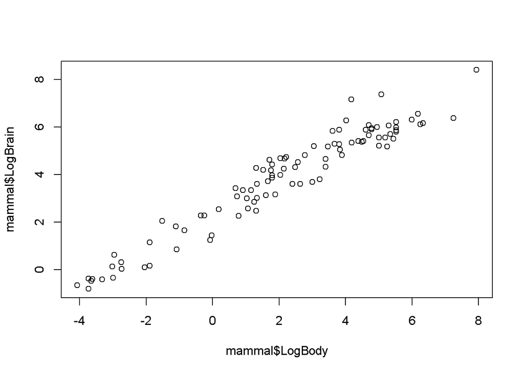

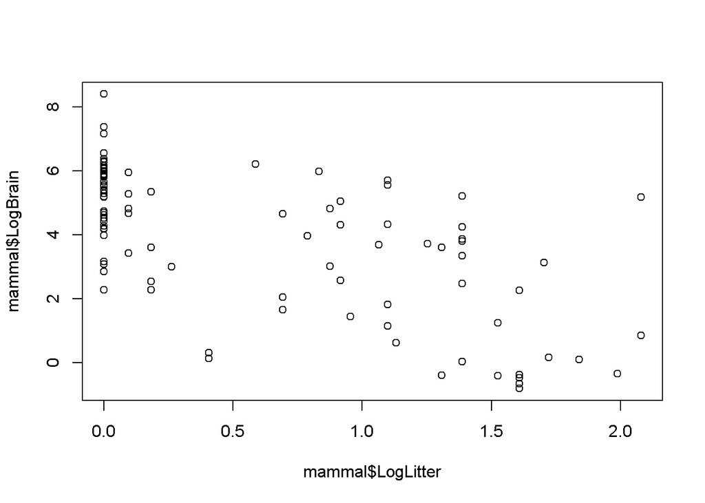

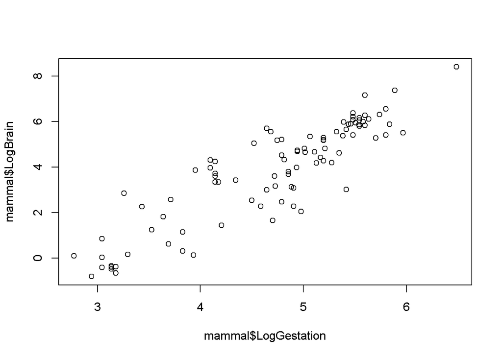

```r
mammal <- read.csv("file:///C:/Users/Joseph/Documents/R/IDS 702/Ex0912.csv", header = T)

mammal$LogBody <- log(mammal$Body)
mammal$LogLitter <- log(mammal$Litter)
mammal$LogBrain <- log(mammal$Brain)
mammal$LogGestation <- log(mammal$Gestation)

plot(mammal$LogBrain ~ mammal$LogBody + mammal$LogLitter + mammal$LogGestation, data = mammal, ask=T)
```

### Part B. Regression Model of Log Brain on the other variables

```r
logMam <- lm(mammal$LogBrain ~ mammal$LogBody + mammal$LogLitter + mammal$LogGestation, data = mammal)
summary(logMam)
```

```
##
## Call:
## lm(formula = mammal$LogBrain ~ mammal$LogBody + mammal$LogLitter +
##     mammal$LogGestation, data = mammal)
##
## Residuals:
##      Min       1Q   Median       3Q      Max
## -0.95415 -0.29639 -0.03105  0.28111  1.57491
##
## Coefficients:
##                     Estimate Std. Error t value Pr(>|t|)
## (Intercept)          0.85482    0.66167   1.292  0.19962
## mammal$LogBody       0.57507    0.03259  17.647  < 2e-16 ***
## mammal$LogLitter    -0.31007    0.11593  -2.675  0.00885 **
## mammal$LogGestation  0.41794    0.14078   2.969  0.00381 **
## ---
## Signif. codes:  0 '***' 0.001 '**' 0.01 '*' 0.05 '.' 0.1 ' ' 1
##
## Residual standard error: 0.4748 on 92 degrees of freedom
## Multiple R-squared:  0.9537, Adjusted R-squared:  0.9522
## F-statistic: 631.6 on 3 and 92 DF,  p-value: < 2.2e-16
```

# Question 2. Brain Weights (Contniued)

### Part C. Regression model with Log of Litter Size vs model with not transformed Litter size.

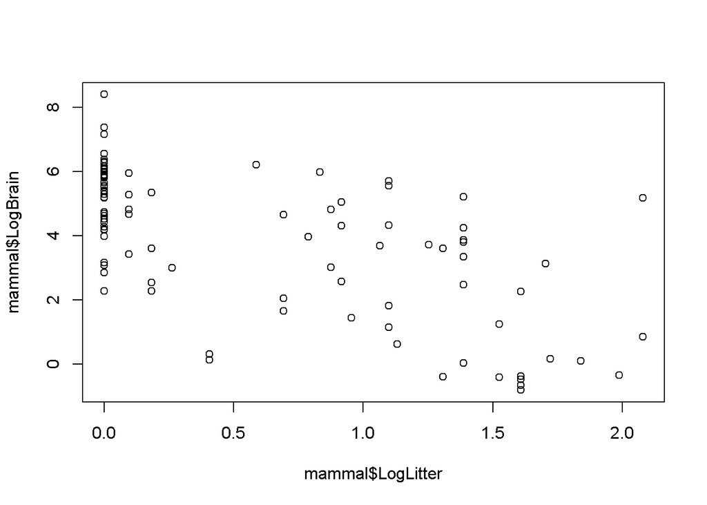

```r
plot(mammal$LogBrain ~ mammal$LogLitter, data = mammal, ask=T)
```

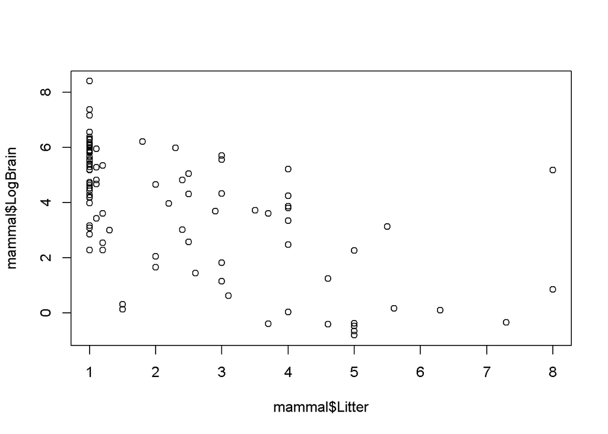

```r
plot(mammal$LogBrain ~ mammal$Litter, data = mammal, ask=T)
```

From a comparison of the scatter plots; Log of Litter size seems to be more evenly spread out compared to an untransformed litter size which looks like it is pinching in (as opposed to fanning out) on the right side. This would lead me to believe that log of litter size would create a more accurate model because the distance from all the points would be reduced.

### Part D. Data for the Regression Model using an untransformed Litter Size

```r
litterMam <- lm(mammal$LogBrain ~ mammal$LogBody + mammal$Litter + mammal$LogGestation, data = mammal)
summary(litterMam)
```

```
##
## Call:
## lm(formula = mammal$LogBrain ~ mammal$LogBody + mammal$Litter +
##     mammal$LogGestation, data = mammal)
##
## Residuals:
##      Min       1Q   Median       3Q      Max
## -0.93895 -0.27922 -0.00929  0.28646  1.59743
##
## Coefficients:
##                     Estimate Std. Error t value Pr(>|t|)
## (Intercept)          0.82338    0.66206   1.244  0.21678
## mammal$LogBody       0.57455    0.03264  17.601  < 2e-16 ***
## mammal$Litter       -0.11038    0.04227  -2.611  0.01053 *
## mammal$LogGestation  0.43964    0.13698   3.210  0.00183 **
## ---
## Signif. codes:  0 '***' 0.001 '**' 0.01 '*' 0.05 '.' 0.1 ' ' 1
##
## Residual standard error: 0.4756 on 92 degrees of freedom
## Multiple R-squared:  0.9535, Adjusted R-squared:  0.952
## F-statistic: 629.4 on 3 and 92 DF,  p-value: < 2.2e-16
```

```r
confint(litterMam)
```

```
##                          2.5 %      97.5 %
## (Intercept)         -0.4915254  2.13829063
## mammal$LogBody       0.5097143  0.63937813
## mammal$Litter       -0.1943220 -0.02643223
## mammal$LogGestation  0.1675856  0.71169994
```

From this we can see that the littersize can be expected to decrease the brain size by 0.026 and 0.19 when taking the natural litter size as opposed to the log.

### Part E. Comparison of models using R-Squared and Residual Plots

However when interpreting the data for modeling, it is more effecient to use log of litter size (as you can now use exp agianst the model to quickly determine the brain size estimates/predictions).

# Question 3. Winning Speeds at the Kentucky Derby

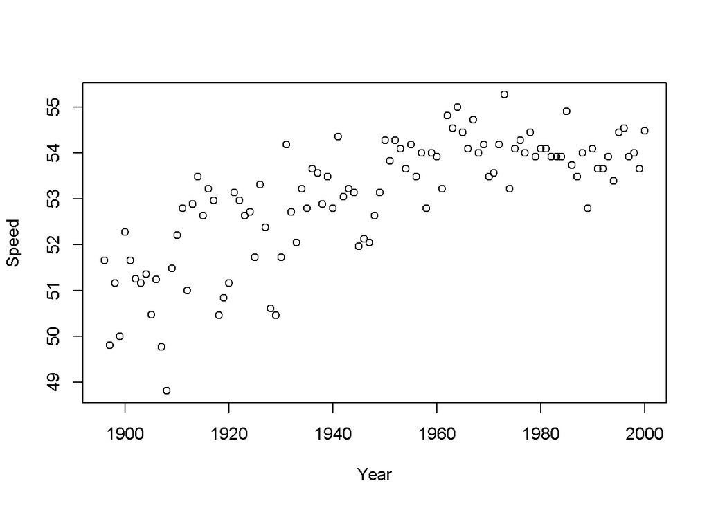

```r
derby <- read.csv("file:///C:/Users/Joseph/Documents/R/IDS 702/Ex0920.csv", header = T)
plot(y = derby$Speed, x = derby$Year, xlab = "Year", ylab = "Speed" )
```

Initially during analysis I plotted the data as a function of Speed over years. This scatterplot clearly showed a logrithmic function, which logically made since, as horse raving became more refined, they would ultimately reach an apex of peak performance. The variance between the upper and lower speeds was not readily apparent.

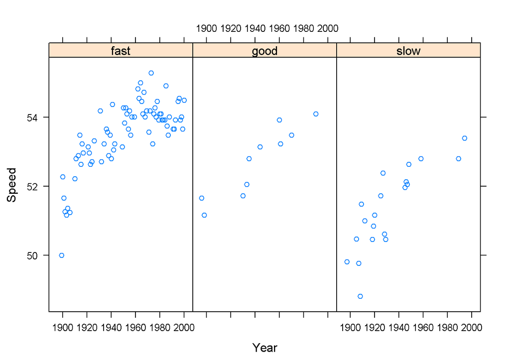

```r
library(lattice)
xyplot(Speed ~ Year | Condition, data = derby)
```

Next I looked at the data and it’s interaction with conditions. Here it was clear that conditions influenced race speeds in a relatively constant way.

```r
#transformations after looking at the intial plot
derby$cSpeed <- derby$Speed - mean(derby$Speed)
derby$Year2 <- (derby$Year)^2

#creating the model with condition fast being the baseline
DerbyModel <- lm(cSpeed ~ Year + Year2 + as.factor(Condition), data = derby)
summary(DerbyModel)
```

```
##
## Call:
## lm(formula = cSpeed ~ Year + Year2 + as.factor(Condition), data = derby)
##
## Residuals:
##      Min       1Q   Median       3Q      Max
## -1.60905 -0.30796 -0.02224  0.38851  1.10047
##
## Coefficients:
##                            Estimate Std. Error t value Pr(>|t|)
## (Intercept)              -1.651e+03  2.476e+02  -6.667 1.45e-09 ***
## Year                      1.669e+00  2.543e-01   6.563 2.37e-09 ***
## Year2                    -4.214e-04  6.526e-05  -6.457 3.89e-09 ***
## as.factor(Condition)good -5.319e-01  1.862e-01  -2.857   0.0052 **
## as.factor(Condition)slow -1.610e+00  1.439e-01 -11.189  < 2e-16 ***
## ---
## Signif. codes:  0 '***' 0.001 '**' 0.01 '*' 0.05 '.' 0.1 ' ' 1
##
## Residual standard error: 0.5492 on 100 degrees of freedom
## Multiple R-squared:  0.8365, Adjusted R-squared:  0.8299
## F-statistic: 127.9 on 4 and 100 DF,  p-value: < 2.2e-16
```

For this question I felt the following transformations were needed;

First, Mean centering the speed to ensure speeds were more easily interpretated. Second I used Year^2 in order to remove the curve from the scatterplot, to more acurately fit a line.

Interpreting this data, we can see that condition fast was used as a baseline. Because of this we can expect Speed (which is measured in feet per second) decreases by 0.5 as we move from fast to good conditions, and 1.6 as we move to slow compared speed for each year.

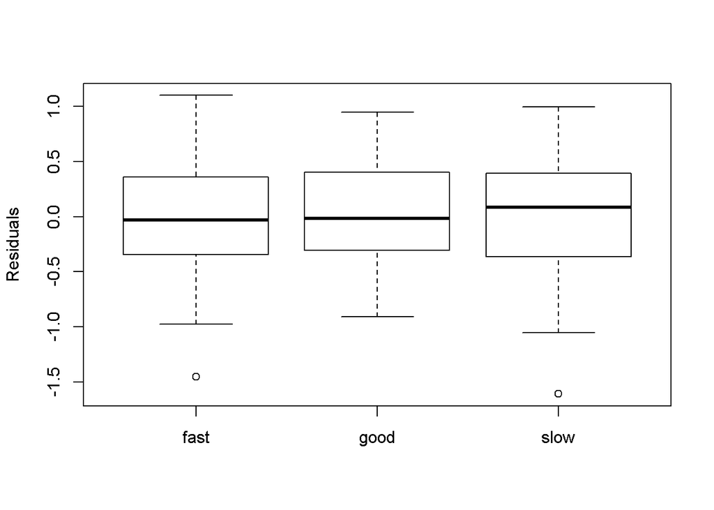

```r
#checking the residuals
boxplot(DerbyModel$resid ~ derby$Condition, ylab = "Residuals")
```

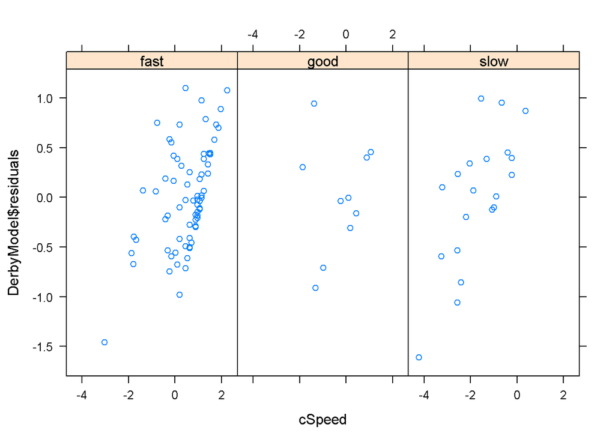

```r
xyplot(DerbyModel$residuals ~ cSpeed | Condition, data = derby)
```

Looking at the residuals we can see that the model is fairly accurate and based on each condition we can determine how fast a winning horse will run each derby. This is show by each conditional residual being balanced across the 0.0 line

# Question 4. Old Faithful eruption times by day

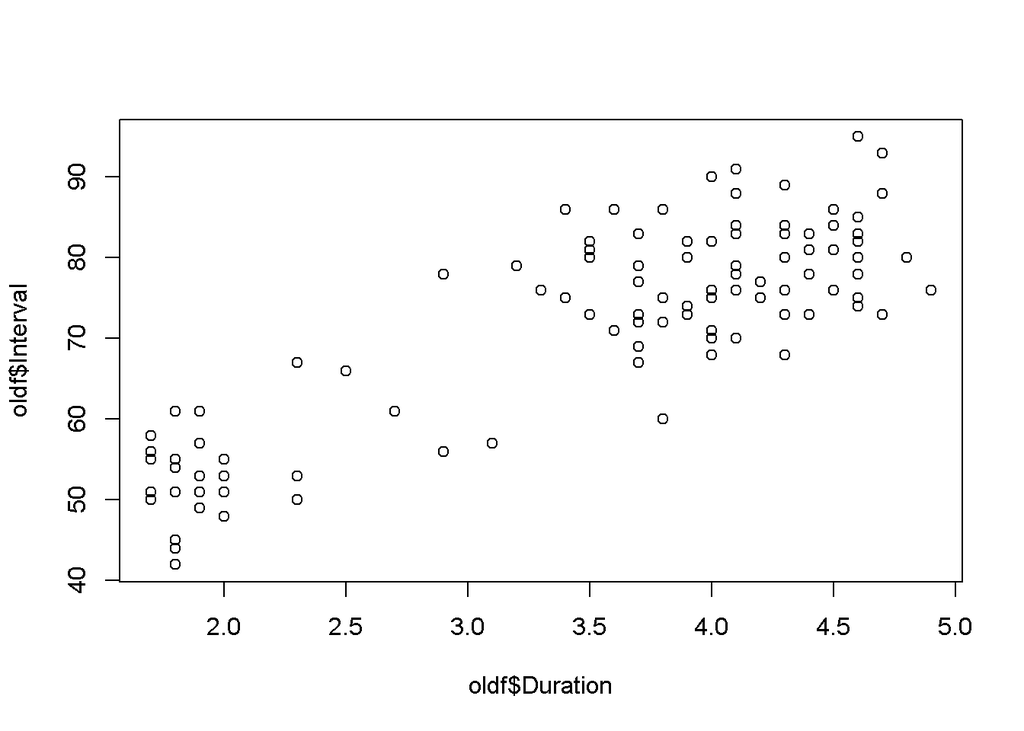

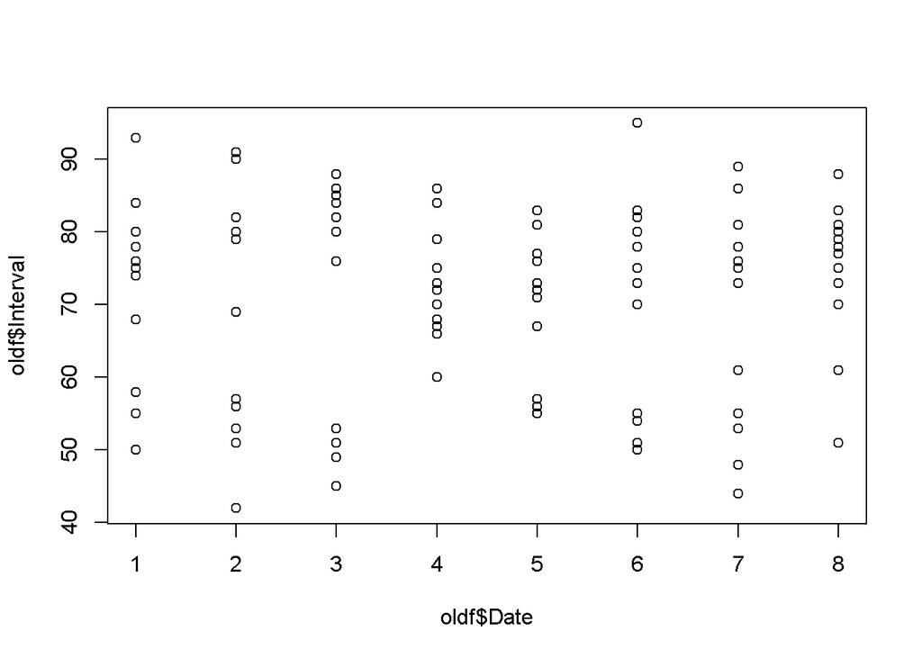

```r
oldf <- read.csv("file:///C:/Users/Joseph/Documents/R/IDS 702/Ex1015.csv", header = T)
plot(oldf$Interval ~ oldf$Duration + oldf$Date, data = oldf, ask=T)
```

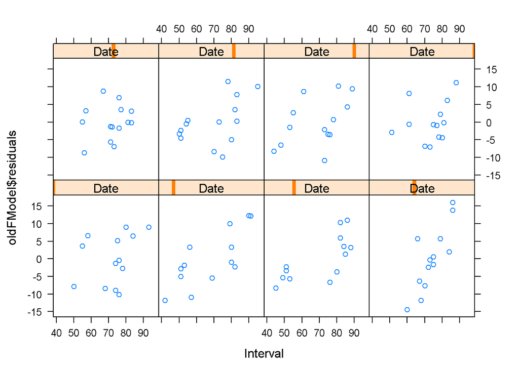

```r
# create a model of wait times per day
otheroldfModel <- lm(Interval ~ Duration, data = oldf)
oldFModel <- lm(Interval ~ Duration + as.factor(Date), data = oldf)
# Checking the models through plots
xyplot(oldFModel$residuals ~ Interval | Date, data = oldf)
```

```r
anova(otheroldfModel, oldFModel)
```

```
## Analysis of Variance Table
##
## Model 1: Interval ~ Duration
## Model 2: Interval ~ Duration + as.factor(Date)
##   Res.Df    RSS Df Sum of Sq      F Pr(>F)
## 1    105 4689.0
## 2     98 4620.2  7    68.853 0.2086 0.9828
```

In comparison to the previous model, we can see that when using days as a factor does not effect the model in a significant way.

# Question 5. Wages and Race.

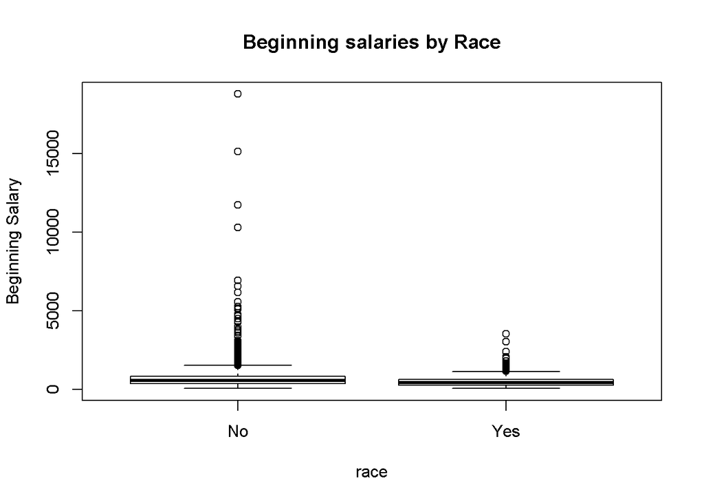

```r
wagerace <- read.csv("file:///C:/Users/Joseph/Documents/R/IDS 702/Ex1029.csv", header = T)
boxplot(Wage ~ Black, data = wagerace, xlab = "race", ylab = "Beginning Salary", main = "Beginning salaries by Race")
```

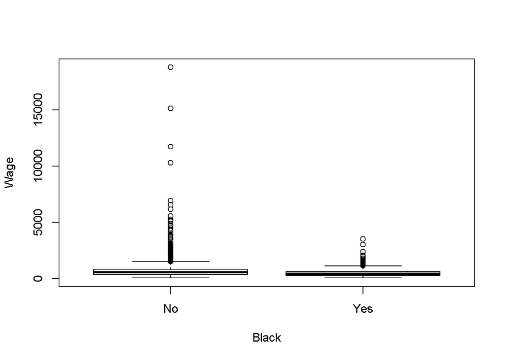

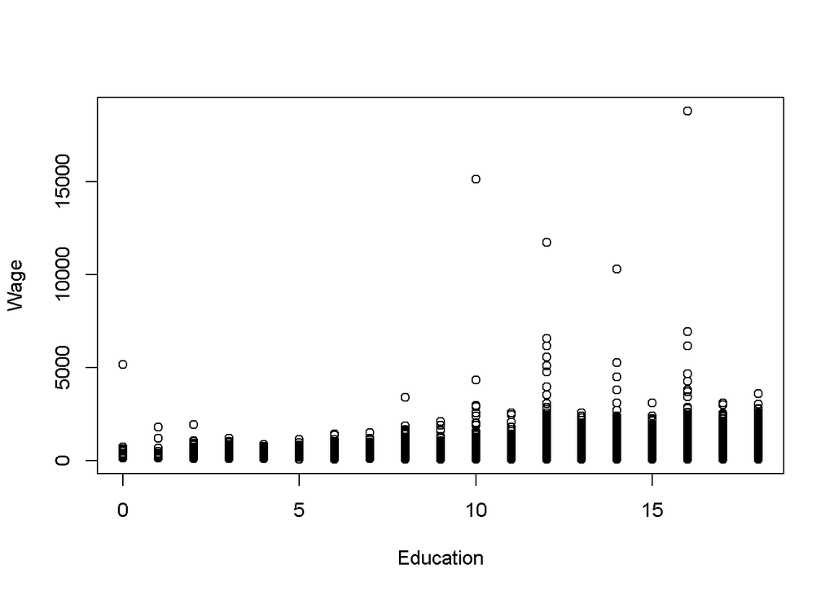

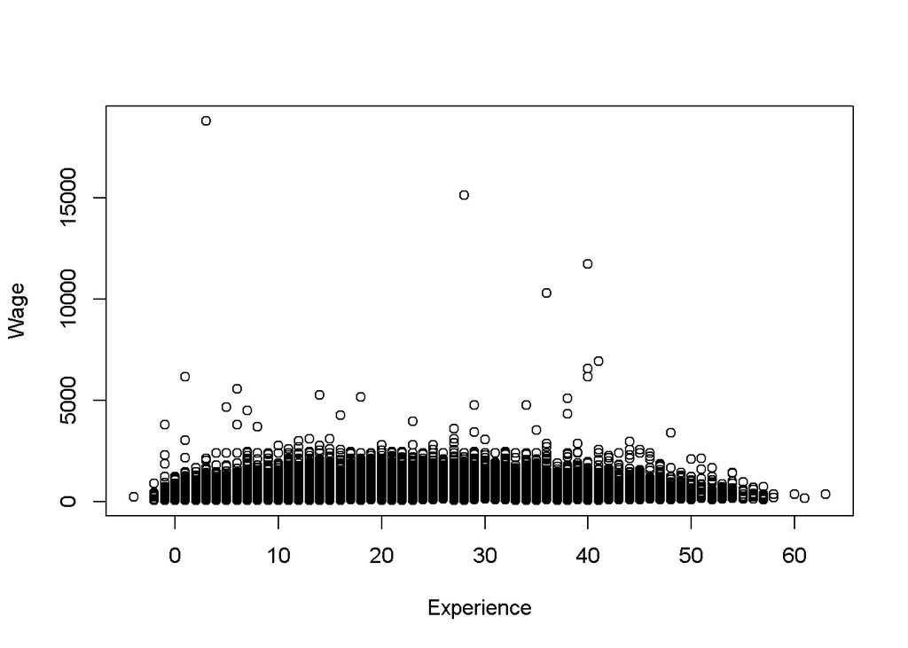

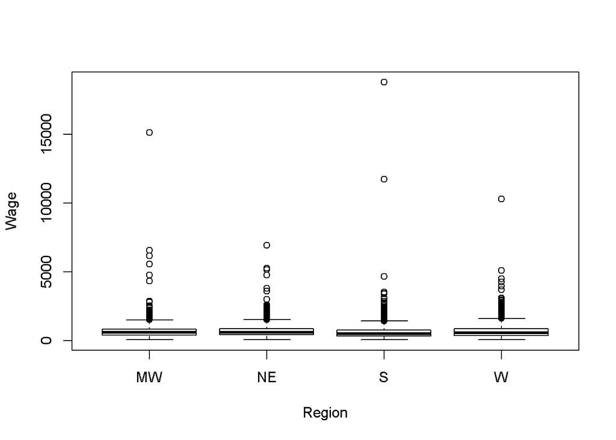

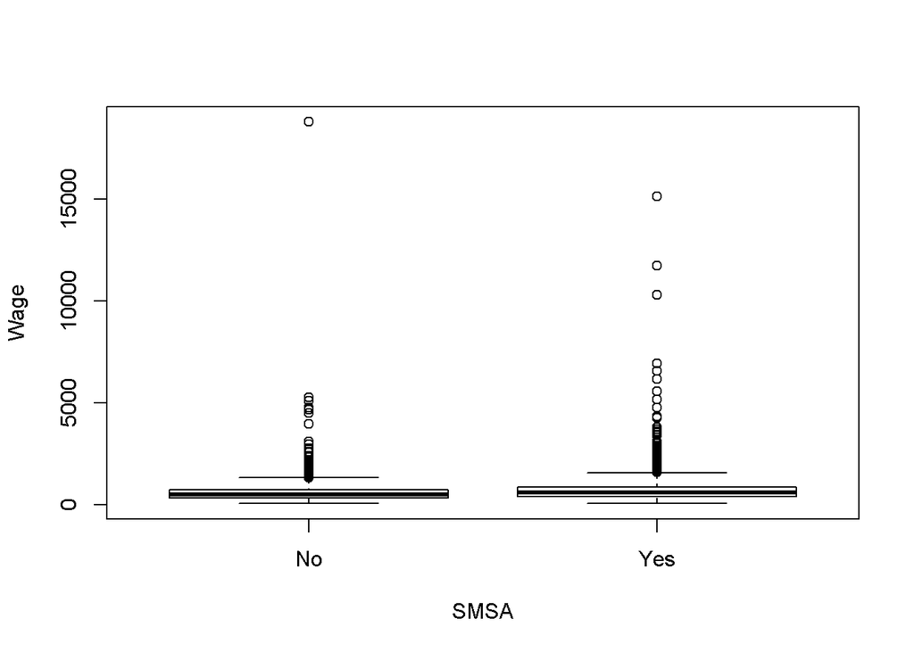

```r
plot(Wage ~ Black + Education + Experience + Region + SMSA, data = wagerace, ask = T)
```

As with question 3, during the exploritory data analysis I plotted the data. If became obvious that there was a difference between black males and their counterparts in salary. This was particularly evident in amount of outliers.

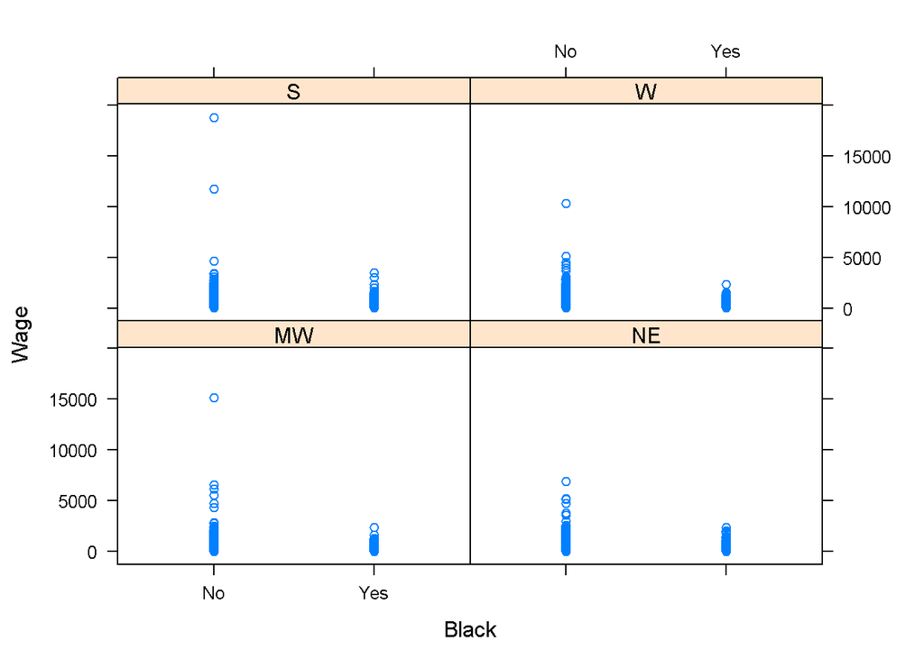

```r
xyplot(Wage ~ Black | Region, data = wagerace )
```

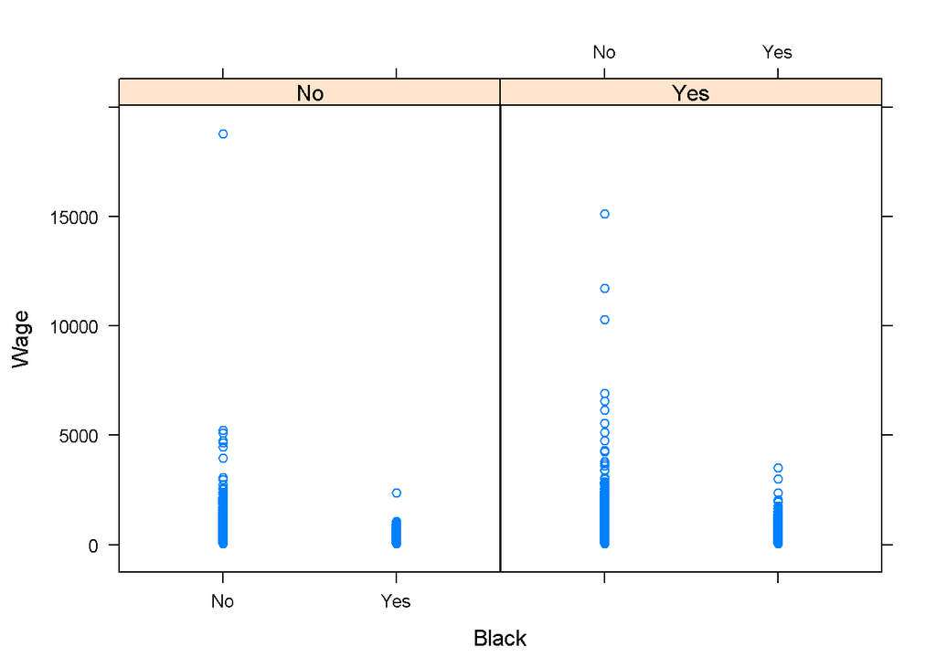

```r
xyplot(Wage ~ Black | SMSA, data = wagerace)
```

Further analysis by region and SMSA show that black men earn a much tighter variance than their non black counterparts without regards to education and expereince. This variance as a whole is also less than their non black counterparts, which warrants the additional investigation of their effect on the data.

```r
LogWage <- log(wagerace$Wage)
Education2 <- (wagerace$Education)^2
Experience2 <- (wagerace$Experience)^2

wagemodel <- lm(LogWage ~ as.factor(Black) * as.factor(Region) + Education + Education2 + Experience + Experience2 + as.factor(SMSA), data = wagerace)
summary(wagemodel)
```

```
##
## Call:
## lm(formula = LogWage ~ as.factor(Black) * as.factor(Region) +
##     Education + Education2 + Experience + Experience2 + as.factor(SMSA),
##     data = wagerace)
##
## Residuals:
##     Min      1Q  Median      3Q     Max
## -2.7628 -0.2887  0.0357  0.3281  3.9011
##
## Coefficients:
##                                           Estimate Std. Error t value
## (Intercept)                              4.721e+00  3.666e-02 128.780
## as.factor(Black)Yes                     -2.358e-01  2.933e-02  -8.039
## as.factor(Region)NE                      4.069e-02  9.603e-03   4.237
## as.factor(Region)S                      -6.640e-02  9.104e-03  -7.293
## as.factor(Region)W                      -2.038e-02  9.711e-03  -2.098
## Education                                3.666e-02  5.340e-03   6.866
## Education2                               2.094e-03  2.112e-04   9.911
## Experience                               5.658e-02  8.875e-04  63.755
## Experience2                             -8.765e-04  1.925e-05 -45.525
## as.factor(SMSA)Yes                       1.586e-01  7.450e-03  21.290
## as.factor(Black)Yes:as.factor(Region)NE  1.621e-02  4.121e-02   0.393
## as.factor(Black)Yes:as.factor(Region)S  -3.049e-03  3.349e-02  -0.091
## as.factor(Black)Yes:as.factor(Region)W   5.864e-02  4.904e-02   1.196
##                                         Pr(>|t|)
## (Intercept)                              < 2e-16 ***
## as.factor(Black)Yes                     9.43e-16 ***
## as.factor(Region)NE                     2.27e-05 ***
## as.factor(Region)S                      3.11e-13 ***
## as.factor(Region)W                        0.0359 *
## Education                               6.75e-12 ***
## Education2                               < 2e-16 ***
## Experience                               < 2e-16 ***
## Experience2                              < 2e-16 ***
## as.factor(SMSA)Yes                       < 2e-16 ***
## as.factor(Black)Yes:as.factor(Region)NE   0.6941
## as.factor(Black)Yes:as.factor(Region)S    0.9275
## as.factor(Black)Yes:as.factor(Region)W    0.2319
## ---
## Signif. codes:  0 '***' 0.001 '**' 0.01 '*' 0.05 '.' 0.1 ' ' 1
##
## Residual standard error: 0.5108 on 25618 degrees of freedom
## Multiple R-squared:  0.3373, Adjusted R-squared:  0.337
## F-statistic:  1087 on 12 and 25618 DF,  p-value: < 2.2e-16
```

For transformation I used Education and Experience squared. This allowed the model to fit more accurately since both had a parabolic shape through the initial data analysis.